# bioinfomodule 2025

## Principal Component Analysis and Scatter plots.

We’ll first get an overview of the data by plotting the first two components of a PCA. This will give us an overview of how similar the samples are to each other and if we have any batch effects to expect from the differing datasets.

### What is a PCA?

A Principal Component Analysis, short PCA, is a (linear) dimension reduction technique and therefore can be counted to classical unsupervised machine learning. It’s been around since 1901 and basically computes linear combinations that represent the variance in the data best. To do that, it starts with the longest axis in the data, by minimizing the distance of each point in the data to the first linear combination it computes: The first principal component (PC). This GIF gives a good intuition whats happening under the hood:

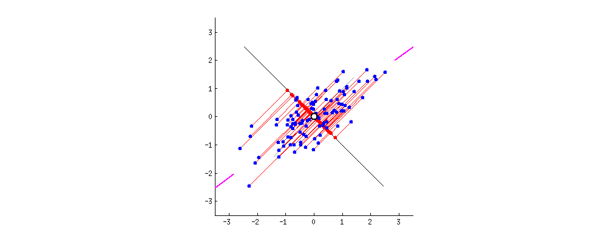

*Figure 4: Minimization of distances to a line in 2D space. The process is repeated incrementally, but every following PC must be orthogonal to all its predecessors, to ensure the PCs do not overlap in information about the underlying variance of the data. The image below shows three PCs fitted to an ellipsoid.*

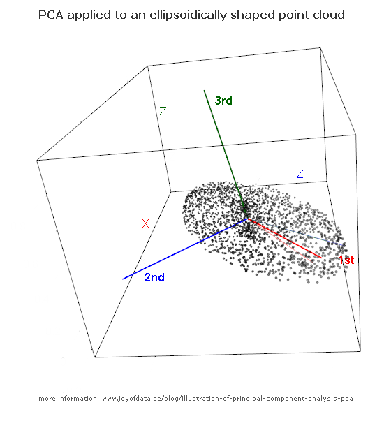

PCA2

*Figure 5: Three PCs fitted to an elipsoid in 3D space, notice how the first PC is in parallel to the longest axis of the ellipsoid and the others are orthogonal to it and each other.

The thread I found these images in, is from crossvalidated, a sub-site of stackexchange, where one can often find answers to questions regarding statistics and machine learning. I recommend to check out the thread, it has a number of answers, ranging from very mathematical to much more intuitive explanations (as hopefully given above :D) Link: https://stats.stackexchange.com/questions/2691/making-sense-of-principal-component-analysis-eigenvectors-eigenvalues *

### And a Scatterplot?

A scatterplot is the most simple plot you can come up with, it plots two numerical variables against each other leading to a 2D point cloud. We’ll plot the first two principal components against each other, as we’ll see in a minute.

### Exercise 5: computing Principal Components and use them for Exploratory Analysis

```r
# a) compute PCs
pca_obj <- prcomp(...)
df_plot <- pca_obj$x %>% as_tibble(rownames="ID")


# b) add metadata
# to add the metadata by a shared variable, we first add the metadata, then have to make the rownames into the
# 'ID' column again, and then  merge the df_plot with left_join by their 'ID'
df_plot <- metadata_combined %>%
  ...
```

```r
# Solution:
# compute PCs
pca_obj <- prcomp(counts_combined)
df_plot <- pca_obj$x %>% as_tibble(rownames="ID")

pca_GSE64912 <- prcomp(counts_GSE64912)
df_plot_GSE64912 <- pca_GSE64912$x %>% as_tibble(rownames="ID")

pca_GSE68799 <- prcomp(counts_GSE68799)
df_plot_GSE68799 <- pca_GSE68799$x %>% as_tibble(rownames="ID")


# add metadata
df_plot <- metadata_combined %>%
  rownames_to_column("ID") %>%
  left_join(df_plot, by = "ID")

df_plot_GSE64912 <- metadata_GSE64912 %>%
  rownames_to_column("ID") %>%
  left_join(df_plot_GSE64912, by = "ID")

df_plot_GSE68799 <- metadata_GSE68799 %>%
  rownames_to_column("ID") %>%
  left_join(df_plot_GSE68799, by = "ID")
```

### Exercise 6: Plotting the information together with metadata.

Now we’ll want to plot the first two principal components as a scatterplot. For this we’ll need functions from ggplot2, which is part of the tidyverse.

ggplot2 has its own pipe-operator to chain together functions that manipulate the final plot, which is +.

To illustrate how ggplot works, we’ll plot the density of the first gene in our count Matrix. For this we’ll use our original combined_data variable, as its format allows us to include metadata without joining. We’ll load a library called scales that allows us to easily change the color of fill or color of our plots. You can look at a tutorial on how ggplot is used here (https://r-statistics.co/Complete-Ggplot2-Tutorial-Part1-With-R-Code.html)

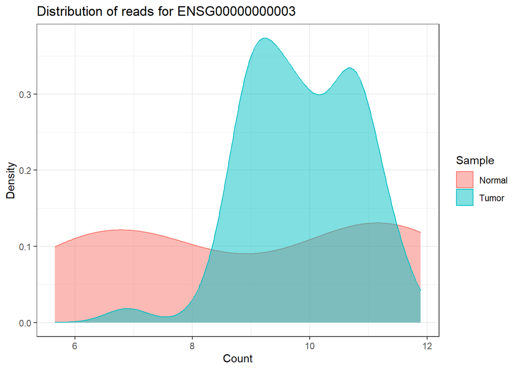

```r
# we'll need this for easy different color scales :)
library(scales)

# Filter for the gene of interest
plt <- combined_data %>%
  select(ID, class, dataset, ENSG00000000003) %>%
  ggplot(aes(x = ENSG00000000003, fill = class, color = class)) +
  geom_density(alpha = 0.5) +
  labs(title = paste("Distribution of reads for", "ENSG00000000003"),
       x = "Count",
       y = "Density",
       fill = "Sample",
       color = "Sample") +
  theme_bw()
# as you saw, plots can also be saved as objects, they can be called to show them or saved with ggsave()
plt
```

We directly see a clear difference, let’s have a look what changes, when we change either fill or color to dataset instead of class. You can add scale_fill_brewer(palette = “Dark2”) + scale_color_brewer(palette = “Set1”) to change the colors of fill and color respectively.

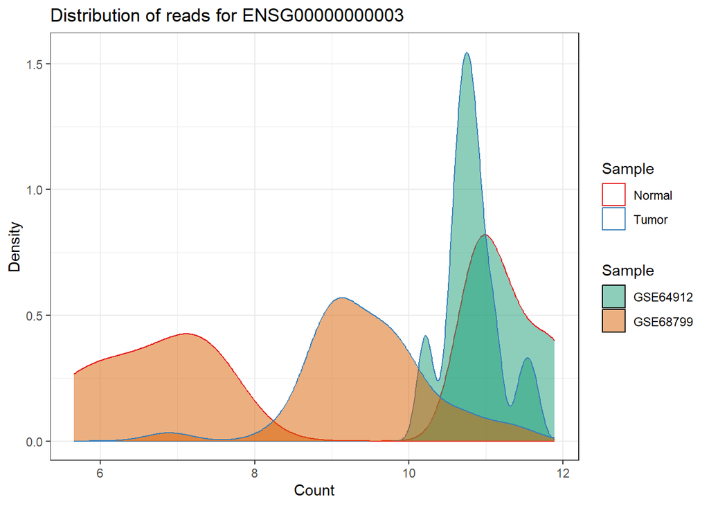

Now use what you saw above with your dataframe containing the PCs and metadata. Use the geom_point() function to plot a scatterplot! Save the plot with the ggsave() function in the out.dir.

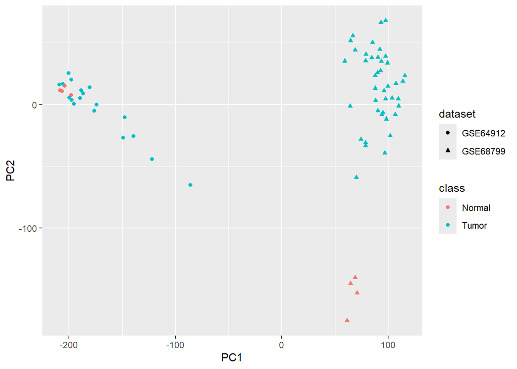

```r
# Exercise 2.2
# you can acess the columns of df_plot for x, y, class and shape like in the example for exercise 6
# then, to create a scatterplot, add geom_point()
plt <- df_plot %>%
  ggplot(aes(...)) +
  ...

#or:
plt <- ggplot(df_plot, aes(...)) +
  ...

#to see the plot at the end:
plt
```

What you can see, if you made it work, is a classic Batch effect! The main variance in the dataset (first PC) is explained by the difference between the dataset. Feel free to experiment a bit and check how the PCA scatter plot looks like for the respective datasets alone!

**Batch effects and other artifacts:** Artifacts is a word for underlying factors that effect the data we are working with, but are not associated with the biological observation. By distorting the gene counts or introducing biases of other nature, they will impact the downstream analysis and lead to false results. The most abundant and impactful are the batch effects, which stem from technical differences in the experimental phase of an assay: Different Handlers, reagents, machines are just a few sources for them. Sometimes they correlate well with differences in quality of a sample, as we showed in one of the works of the Automated Quality Control box. We’ll see how to handle them in later sections.

### Excersise 7: Screeplots and percentage of Variance explained.

Principal components can tell us a lot about the data, the more you need to adequately describe its variance, the more diverse it is. It is interesting for us to see how much variance is actually covered by the PCs. First we’ll get the standard deviations, which are stored in our PCA object inspect the object to see in which part of it they could be stored. Don’t forget that we’ll need to square the standard deviation to get the variance!

```r
# first we'll get the standard deviations, which are stored in our PCA object
# inspect the object to see in which part of it they could be stored.
# don't forget that we'll need to square the standard deviation to get the variance!
# Then we Create a data frame for the scree plot
# the $ operator lets us use the contents of pca_obj in R

scree_data <- data.frame(
  PC = paste("PC", 1:length(pca_obj$...)),
  Variance =  pca_obj$... ...
)
# we'll just take the first 20
scree_data <- scree_data[1:20,]

# now we can create a scree plot which basically plots the PCs in their order
# and the respective variance explained by them.
# you can use aes(x = reorder(PC, Variance, decreasing=T), y = Variance)) to order the PCs by their variance instead of their
# alphabetical order
plt <- ggplot(scree_data, ...
```

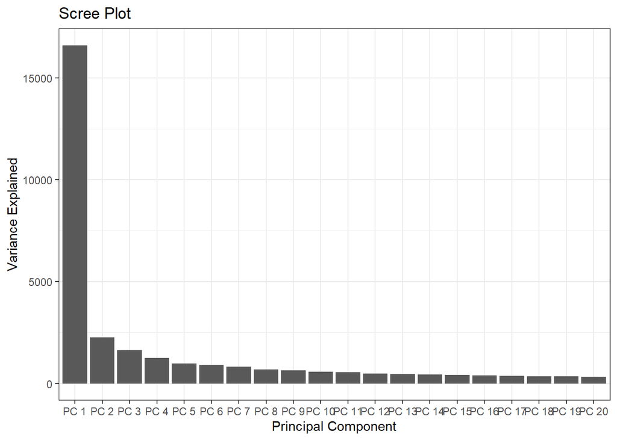

```r
# Solution:
scree_data <- data.frame(
  PC = paste("PC", 1:length(pca_obj$sdev)),
  Variance = (pca_obj$sdev)^2
)

# We'll just take the first 20
scree_data <- scree_data[1:20, ]

# now we can create a scree plot which basically plots the PCs in their order
# and the respective variance explained by them.
plt <- ggplot(scree_data, aes(x = reorder(PC, Variance, decreasing=T), y = Variance)) +
  geom_bar(stat = "identity") +
  labs(title = "Scree Plot",
       x = "Principal Component",
       y = "Variance Explained") +
  theme_bw()
plt
```

Additionally we can compute the percentage of variance that each of the PCs explains as follows:

```r
#hint: perhaps you already encountered these numbers when inspecting the pca_obj with summary?
percentage <- round(pca_obj$sdev^2 / sum(pca_obj$sdev^2) * 100, 2)
percentage
```

```
##  [1] 42.12  5.76  4.14  3.15  2.47  2.29  2.06  1.74  1.64  1.45  1.39  1.25
## [13]  1.20  1.10  1.06  1.01  0.94  0.91  0.87  0.86  0.83  0.82  0.80  0.76
## [25]  0.75  0.72  0.71  0.69  0.68  0.66  0.63  0.61  0.60  0.58  0.56  0.56
## [37]  0.55  0.54  0.53  0.52  0.50  0.49  0.47  0.46  0.45  0.44  0.43  0.43
## [49]  0.42  0.41  0.40  0.39  0.38  0.36  0.36  0.34  0.33  0.31  0.31  0.30
## [61]  0.29  0.28  0.27  0.26  0.24  0.16  0.00
```

So the batch effect we observed on the PCA plot quite drastically is actually generating 42% of the Variance in our data! Can you tell me what it could mean that a principle component explains variance in the data? What does this Scree plot explain to us?

## Differential Expression Analysis

### Foreword

Differential expression analysis is a key step in interpreting RNA-seq data, aiming to identify genes whose expression levels differ significantly between conditions. This process can reveal important insights into biological processes and diseases.

Classical statistical methods, such as t-tests, may not work well for RNA-seq data due to its unique characteristics. RNA-seq data is typically overdispersed, meaning the variance exceeds the mean, violating the assumptions of many classical statistical methods. Additionally, RNA-seq data is count-based and often has a large number of zero counts, which can lead to false positives or negatives when using classical methods.

To address these challenges, specialized statistical methods and tools have been developed for differential expression analysis of RNA-seq data, such as DESeq2, edgeR, and limma-voom. These methods account for the overdispersion and count-based nature of RNA-seq data, providing more accurate and reliable results.

The process typically involves data normalization, dispersion estimation, and hypothesis testing. The result is a list of genes ranked by significance, along with statistics such as fold change and false discovery rate (FDR).

In summary, differential expression analysis is a powerful tool for identifying genes that are differentially expressed between conditions, providing valuable insights into the underlying biology. However, it’s important to use appropriate statistical methods and tools that account for the unique characteristics of RNA-seq data.

### Limma

Limma (Linear Models for Microarray Data) is a widely used R package for the analysis of gene expression data, including both microarray and RNA-seq data. Limma was originally developed for the analysis of microarray data, but has since been adapted for the analysis of RNA-seq data using the voom transformation.

The voom (variance modeling at the observation level) transformation is used to transform RNA-seq count data into a format that can be analyzed using linear models. The voom transformation estimates the mean-variance relationship of the count data and generates a set of weights that are used to account for the variability in the data. These weights are then used in the linear modeling step to improve the accuracy and power of the analysis. We will not use voom, as our data already has been normalized with a method that works similar (DESeq2’s VST).

Limma uses linear models to test for differential expression between conditions, while accounting for various sources of variability, such as batch effects and other covariates. The linear models include design matrices that specify the experimental design and allow for the estimation of log2 fold changes between conditions.

One of the key features of limma is its empirical Bayes method for estimating gene-wise variances. This method borrows information across genes to improve the stability and accuracy of the variance estimates, especially for genes with low counts.

Reference: Ritchie ME, Phipson B, Wu D, Hu Y, Law CW, Shi W, Smyth GK (2015). “limma powers differential expression analyses for RNA-sequencing and microarray studies.” Nucleic Acids Research, 43(7), e47. doi:10.1093/nar/gkv007.

### Exercise 8: Differential expression on a single dataset

Lets start with the basic analysis of our datasets! We’ll see how to handle batch effects in the next chapter. We’ll start with the combined data, and can then also look at the difference between the datasets.

Since it is 2024, and everyone (me included) would probably just ask your favorite AI for at least some information anyways, let’s look at how ChatGPT would handle this (feel free and encouraged to look through guides for Limma and different stuff). I gave it the text from the last passage and asked it, if it can help me with the code for this:

ChatGPT answer: Steps: 1: Prepare the Data: Load your normalized data (already processed with DESeq2’s VST).

2: Set Up Design Matrix: Define the experimental design.

3: Fit the Model: Use limma functions to fit a linear model.

4: Extract Differentially Expressed Genes (DEGs): Filter genes based on adjusted p-values.

5: Visualize Results: Create volcano plots and summaries.

Here is its implementation:

```r
# Load necessary libraries
library(limma)
library(ggplot2)

# Step 1: Load normalized data (assumed to be VST-transformed counts)
# Replace 'normalized_counts' with your actual data object
# Rows: genes, Columns: samples
normalized_counts <- read.csv("GSE68799_vst_normalized.csv", row.names = 1)

# Load metadata
# Ensure metadata includes a column 'Condition' (e.g., "Normal" or "Tumor") for design
metadata <- read.csv("GSE68799_metadata.csv")

# Ensure row names of metadata match column names of normalized_counts
metadata <- metadata[match(colnames(normalized_counts), rownames(metadata)), ]

# Step 2: Set up the design matrix
# Convert condition to a factor
metadata$Condition <- factor(metadata$Condition, levels = c("Normal", "Tumor"))
design <- model.matrix(~0 + Condition, data = metadata)
colnames(design) <- levels(metadata$Condition)

# Step 3: Fit the linear model
fit <- lmFit(normalized_counts, design)

# Define contrasts (e.g., Tumor vs Normal)
contrast_matrix <- makeContrasts(Tumor_vs_Normal = Tumor - Normal, levels = design)

# Apply contrasts to the fit
fit2 <- contrasts.fit(fit, contrast_matrix)

# Apply empirical Bayes moderation
fit2 <- eBayes(fit2)

# Step 4: Extract DEGs
# Set a cutoff for adjusted p-value and log2 fold change
adj_pval_cutoff <- 0.05
logfc_cutoff <- 1

# TopTable gives a ranked table of results
deg_results <- topTable(fit2, coef = "Tumor_vs_Normal", adjust = "BH", number = Inf)

# Filter DEGs by adjusted p-value and logFC
deg_filtered <- subset(deg_results, adj.P.Val < adj_pval_cutoff & abs(logFC) > logfc_cutoff)

# Save DEGs to a file
write.csv(deg_filtered, "DEGs_GSE68799.csv")

# Step 5: Visualization
# Volcano plot
volcano <- ggplot(deg_results, aes(x = logFC, y = -log10(adj.P.Val))) +
  geom_point(alpha = 0.5) +
  geom_hline(yintercept = -log10(adj_pval_cutoff), color = "red", linetype = "dashed") +
  geom_vline(xintercept = c(-logfc_cutoff, logfc_cutoff), color = "blue", linetype = "dashed") +
  labs(title = "Volcano Plot: Tumor vs Normal",
       x = "Log2 Fold Change",
       y = "-Log10 Adjusted P-Value") +
  theme_minimal()

print(volcano)

# Summary of DEGs
cat("Number of DEGs:", nrow(deg_filtered), "\n")
```

This almost works out of the box! Just needs a few changes, so go ahead and do it! Just remember when you work with tools like ChatGPT that you use it as a tool, and not like a fool. Make sure the steps make sense, read about what these steps actually do. What does it actually mean to fit a linear model to something? What does the eBayes do? Is there some false discovery rate detection or correction included? What is the input data (and in which form does it have to be), what happens to it on the way, and what is the output? It can easily happen that you end up with a plot and you don’t even understand what is on there, because we skipped too many steps in the normal process. So it is important to go back and look at them! Or at least ask chatGPT about them (:

here with my own comments included to help you:

[figure not shown]

```r
# Load necessary libraries
library(limma)
library(ggplot2)

# Step 1: Load normalized data (assumed to be VST-transformed counts)
# Replace 'normalized_counts' with your actual data object
# Rows: genes, Columns: samples
normalized_counts <- read.csv("GSE68799_vst_normalized.csv", row.names = 1)

# This for example already exists, it is just called differently. We combined the counts earlier :).
# If you want to stay with the names that chatgpt chose, then:

normalized_counts <- ...

# Load metadata
# Ensure metadata includes a column 'Condition' (e.g., "Normal" or "Tumor") for design
metadata <- read.csv("GSE68799_metadata.csv")

# look in the objects/variables that oyu created what fits in here
metadata <- ...

# this also already exists, it makes sense here, since we have to match the SRR numbers to look what the
# tables look like right now:
# you can also check them in your "Environment" at the top right corner in RStudio
head(normalized_counts) # the rownames are the SRR numbers, the genes are the columns
head(metadata) # the rownames are the SRR numbers, class and dataset are the columns

# Ensure row names of metadata match column names of normalized_counts
metadata <- metadata[match(rownames(...), rownames(...)), ]  # or use colnames when what you want is
# in the columns

# Step 2: Set up the design matrix
# Convert condition to a factor
metadata$Condition <- factor(metadata$Condition, levels = c("Normal", "Tumor"))
design <- model.matrix(~0 + Condition, data = metadata)
colnames(design) <- levels(metadata$Condition)

# Here we have to check what the condition is actually called in our table:
head(metadata_combined) # shows that it is called "class"
# in the example chatgpt thinks that the column is already called Condition
# the best approach would be to now create a new column that has the class information as a factor:
metadata$Condition <- factor(metadata$..., levels = c("Normal", "Tumor"))


# The rest of the model works now (if you gave the variables the right input). it is either good to tell
# an AI what your variables are called, or to change their name so you don't have to adjust it every time

# Step 3: Fit the linear model
fit <- lmFit(normalized_counts, design)

# Define contrasts (e.g., Tumor vs Normal)
contrast_matrix <- makeContrasts(Tumor_vs_Normal = Tumor - Normal, levels = design)

# Apply contrasts to the fit
fit2 <- contrasts.fit(fit, contrast_matrix)

# Apply empirical Bayes moderation
fit2 <- eBayes(fit2)

# Step 4: Extract DEGs
# Set a cutoff for adjusted p-value and log2 fold change
adj_pval_cutoff <- 0.05
logfc_cutoff <- 1

# TopTable gives a ranked table of results
deg_results <- topTable(fit2, coef = "Tumor_vs_Normal", adjust = "BH", number = Inf)

# Filter DEGs by adjusted p-value and logFC
deg_filtered <- subset(deg_results, adj.P.Val < adj_pval_cutoff & abs(logFC) > logfc_cutoff)

# Save DEGs to a file
write.csv(deg_filtered, "DEGs_GSE68799.csv")

# Step 5: Visualization
# Volcano plot
volcano <- ggplot(deg_results, aes(x = logFC, y = -log10(adj.P.Val))) +
  geom_point(alpha = 0.5) +
  geom_hline(yintercept = -log10(adj_pval_cutoff), color = "red", linetype = "dashed") +
  geom_vline(xintercept = c(-logfc_cutoff, logfc_cutoff), color = "blue", linetype = "dashed") +
  labs(title = "Volcano Plot: Tumor vs Normal",
       x = "Log2 Fold Change",
       y = "-Log10 Adjusted P-Value") +
  theme_minimal()

print(volcano)

# Summary of DEGs
cat("Number of DEGs:", nrow(deg_filtered), "\n")
```

Now we do have a number of differentially expressed genes (DEGs), which we can plot, subset and further categorize. This is how such a plot could look like.

Questions: Why would we need to do a differential expression analysis instead of using the counts form the RNA-sequencing directly? Why is this analysis necessary for downstream analysis on gene level?

**P-Values:** The p-value is a statistical measure that helps determine the significance of a hypothesis test. In the context of a moderated t-test, such as the one used in the limma package in R, the p-value represents the probability of observing the test statistic (or a more extreme value) assuming the null hypothesis is true. The null hypothesis typically states that there is no difference between the groups being compared.

The calculation of the p-value in a moderated t-test involves first computing the moderated t-statistic, which takes into account both the observed differences between the groups and the associated uncertainties. This moderated t-statistic is then compared to a t-distribution with appropriate degrees of freedom to obtain the p-value. The degrees of freedom are calculated based on the number of samples and the estimates of gene-wise variances. The p-value obtained from this process indicates the level of evidence against the null hypothesis, with smaller p-values suggesting stronger evidence in favor of the alternative hypothesis (i.e., there is a significant difference between the groups).

### Exercise 9: P-values and Co.

Why do we use the adjusted P-value? Which adjustment method is used by limma?

## Strategies to handle Batch Effects

As previously mentioned, batch effects can have huge impacts on downstream analysis. Modern solutions for differential expression analysis that use linear models to model gene expression, can be fed with additional information about the batches, if these are known. (As in our case). However its important to note, that you can also have artifacts that are not directly correlated with the known batch! For this there are packages such as SVA - Surrogate variable analysis - that provide algorithms for detecting and correcting batch effects.

### Exercise 10 (if you have too much time and will): Run SVA and search for correlations with our Batch.

For this we’ll need to consider a few things: a. To be able to compare our datasets/batches, we’ll need to have a vector containing numbers that represents the batches. You can use %>% mutate() in combination with the ifelse() function to generate a new column in the meta.data, called Batch (or whatever you like).

2. SVA will take in the count data and a design matrix, so the inputs are the same as above. Sva suggests to add another design matrix mod0 for the best results.
3. Now we have both SVs and a numerical batch representation and can use cor() to compute pairwise correlations of the SVs with the batch.

This is really difficult. Don’t be demotivated if you have no idea what to do. Try your best and we will talk about it at the end of todays course :)

You can also run limma and sva on just one of the datasets, but then you can only use the biological group (normal/tumor) instead of batch information.

Other questions to the batch correction: How different can a batch effect look in a PCA or different dimension reduction strategies? Is it always correct to use a statistical approach to remove unknown “noise” when the biological effects themselves are subject of the experiment? How troublesome or problem-free can batch correction be? especially if there is only information about the biological group (i.e. tumor/normal) instead of actual batches? Would you say that in this case, batch information leads to an over-correction? What can an over-correction look like? Can i look at singewl datasets instead of the combined sets to make an easier decision? What would it mean for downstream analysis? Please discuss!

We use the differential expressed gene(deg) results from limma for further analysis.

```
## Number of significant surrogate variables is:  8
## Iteration (out of 5 ):1  2  3  4  5
```

```
## Found 19963 genes with uniform expression within a single batch (all zeros); these will not be adjusted for batch.
```

[output not shown]

[output not shown]

[output not shown]

[output not shown]

[output not shown]

[output not shown]

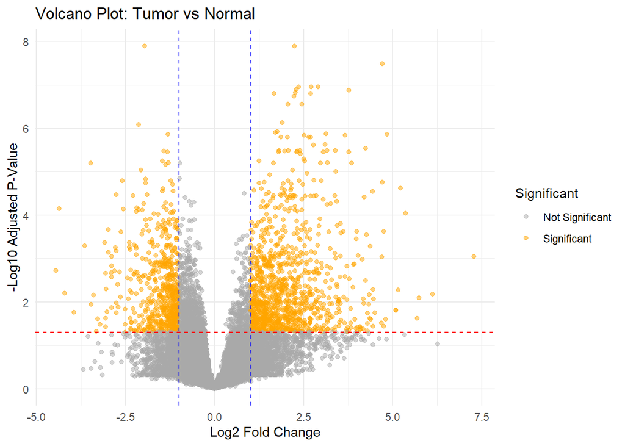

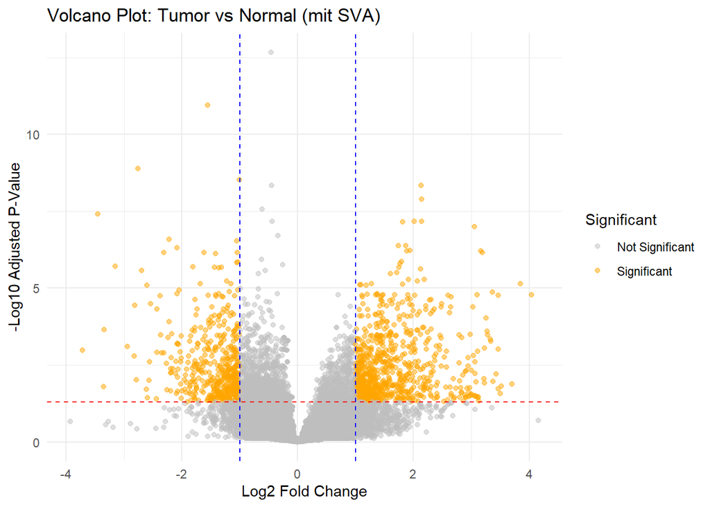

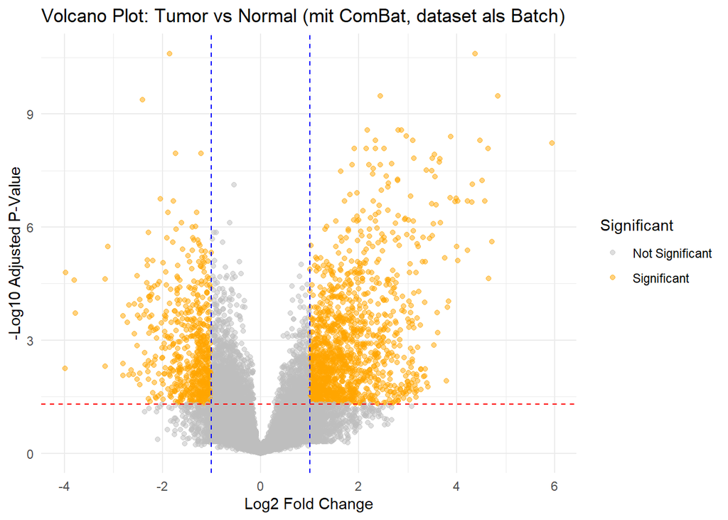

```
## Top 500 DEGs (no batch) vs SVA:    206 in common
```

```
## Top 500 DEGs (no batch) vs ComBat: 322 in common
```

```
## Top 500 DEGs SVA vs ComBat:       267 in common
```

```
## Top 500 DEGs shared by all three: 187
```

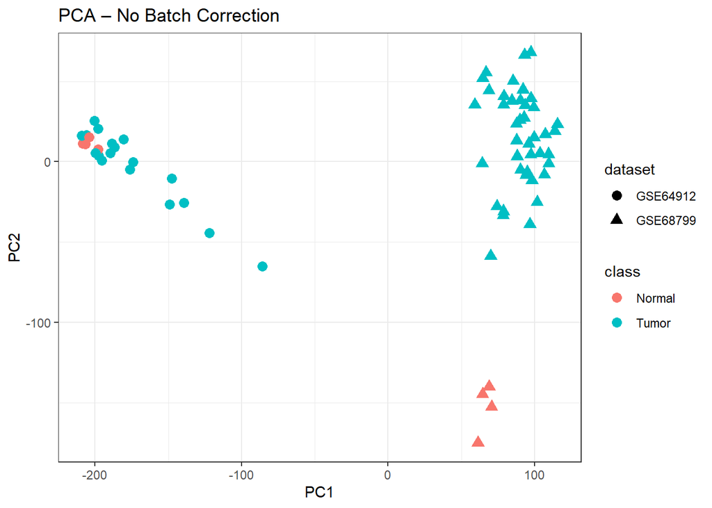

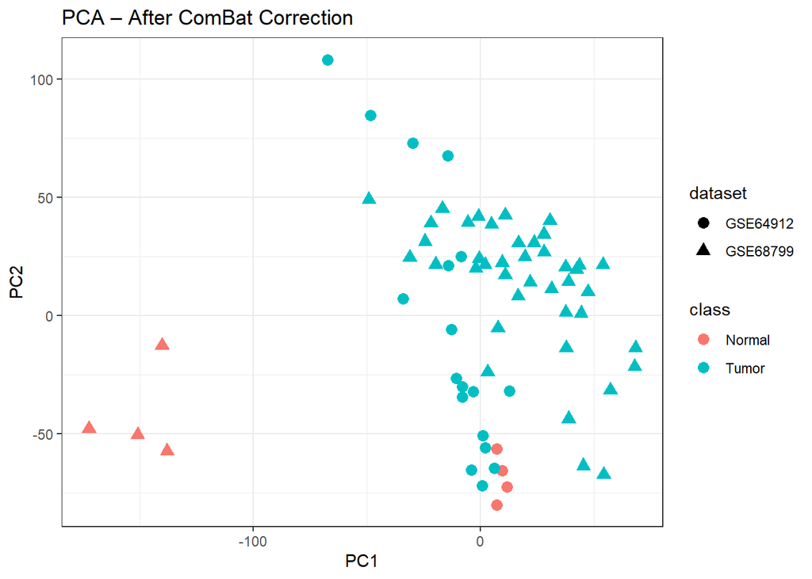

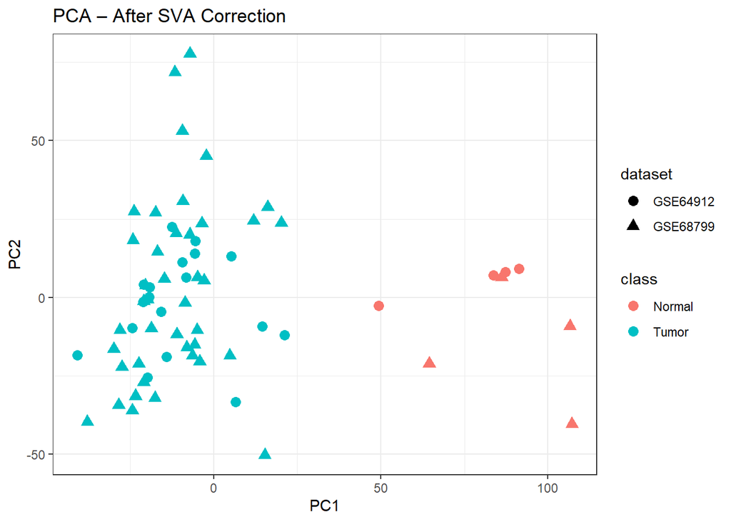

```r
library(sva)
# you might have to use t(counts_combined) depending of your counts_combines is [samples x features]
# or [features x samples] (you can also do:
# counts_combined <- t(counts_combined) to change "permanently")
metadata_sva <- metadata_combined[match(colnames(counts_combined), rownames(metadata_combined)), ]
# needs a column with the biological "condition" or group:
metadata_sva$Condition <- ...

# introduce a new column that gives the different datasets a "1" and "2" depending on the dataset they are from
metadata_sva$Batch <- ifelse(...)
# for the function they need to be factors instead of strings or numbers
metadata_sva$Batch <- factor(...)

#insert correct columns:
design_sva <- model.matrix(~0 + ... + ..., data = metadata_sva)
mod0 <- model.matrix(~..., data = metadata_sva)


# Estimate surrogate variables
sva_obj <- ...

# Create valid names for surrogate variables
colnames(sva_obj$sv) <- paste0("SV", seq_len(ncol(sva_obj$sv)))

# Add surrogate variables to the design matrix
design_with_sv <- ...)

# Create valid names for surrogate variables
# colnames(sva_obj$sv) <- paste0("SV", seq_len(ncol(sva_obj$sv)))

# continue with differential gene expressionand plot
contrast_matrix_sva <- ...

fit_sva <- ...
...
```